# Statistical Analysis of Soil Data

Author

Andrew Kerr, Kyle Bistrain, Rachel Roggenkemper, Liam Quach

## Introduction and Data Preparation

Here, we are loading the data and preparing it for analysis. This includes cleaning the column names, converting data types, and creating new variables that will be useful for modeling.

### Data Read-in

This section reads in the data from the master Excel file. We’ll be working with the combined dataset for the analyses.

```r
# Read in the data from the Excel file
df_combined <- read_xlsx(here::here("data", "Master.xlsx"), sheet = "combined")

# Convert relevant columns to factors for modeling
df_combined <- df_combined %>%
  mutate(
    sample_id = as.factor(sample_id),
    treatment = as.factor(treatment),
    site = as.factor(site),
    block = as.factor(block),
    study_year = as.factor(study_year)
  )

# Define the response variables we'll be analyzing
response_vars <- c("nh4", "no3", "mg", "p", "ec", "p_h")
```

### Handling Values Below the Limit of Detection (LOD)

A common challenge in environmental data is dealing with measurements that are below the limit of detection (LOD). These are recorded as “LOD” in the dataset. We will explore two common approaches to handle these values:

1. **Treating LOD as Censored Data:** This is a more statistically robust approach. It acknowledges that the true value is somewhere between 0 and the LOD, rather than assuming it is exactly 0.
2. **Replacing LOD with 0:** This is a simple approach, but it can bias the results, especially if there are many LOD values.

Here, we create two datasets to reflect these two approaches.

```r
# Create a dataset where LOD is replaced with 0
df_combined_LOD_0 <- df_combined %>%
  mutate(across(
    all_of(response_vars),
    ~ as.numeric(ifelse(.x == "LOD", 0, .x))
  ),

    date = as.factor(date),
    # Create combined grouping factors
    site_block_id = interaction(site, block, drop = TRUE),
    trt_site_block_id = interaction(treatment, site, block, drop = TRUE)
  )

# Create a dataset for censored models
# A 'censored' column is added for each response variable.
# The actual response variable is set to a placeholder (e.g., the detection limit) when censored.
lc_model_data <- df_combined %>%
  mutate(
    nh4_cens = ifelse(nh4 == "LOD", -1, 0),
    no3_cens = ifelse(no3 == "LOD", -1, 0),
    mg_cens = ifelse(mg == "LOD", -1, 0),
    p_cens = ifelse(p == "LOD", -1, 0),

    nh4 = ifelse(nh4 == "LOD", nh4_lod, as.numeric(nh4)),
    no3 = ifelse(no3 == "LOD", n03_lod, as.numeric(no3)),
    mg = ifelse(mg == "LOD", mg_lod, as.numeric(mg)),
    p = ifelse(p == "LOD", p_lod, as.numeric(p)),

    date = as.factor(date),
    # Create combined grouping factors
    site_block_id = interaction(site, block, drop = TRUE),
    trt_site_block_id = interaction(treatment, site, block, drop = TRUE)
  )
```

Depending on which method we use, the models answer slightly different research questions.

#### Treating LOD as 0

- **Assumption**: You are assuming that any measurement below the Limit of Detection (LOD) is a true zero. However, since your data does not have any true zeros this allows us to use a zero-inflated model to model (1) probability below LOD and (2) mean if above LOD.
- **Research Question(s) it Answers**: This approach splits your research question into two parts:
  1. Presence/Absence: Does the treatment affect the probability that the response is LOD?
  2. Concentration when Present: If the response is present (i.e., not LOD), how does the treatment affect its concentration?
- **Downside**: In most environmental systems, a value below the LOD doesn’t mean the response is completely absent, just that its concentration is too low for your equipment to measure accurately. By substituting zero, you are artificially deflating the mean and variance of your data, which can bias your results and lead you to **underestimate the true average concentration**.

#### Treating LOD as Left-Censored

- **Assumption**: You assume that a value below the LOD is not a known value, only that its true concentration is somewhere between 0 and the detection limit. The model doesn’t force it to be zero; it incorporates this uncertainty into the analysis.
- **Research Question(s) it Answers**: This approach answers a single, more direct question: How does the treatment affect the true underlying concentration of the response, while properly accounting for the limitations and uncertainty of the measurement instrument?
- **Advantage**: It doesn’t “invent” data by substituting zero. Instead, it uses all the information you have (i.e., “we know it’s less than X”) to provide a less biased and more accurate estimate of the treatment effects on the actual response concentrations.

### Exploratory Data Analysis

Before we build our models, it’s important to explore the data to understand its structure and identify any patterns or issues.

#### Proportion of Zero/LOD Values

Here, we’ll look at the proportion of zeros (after converting LOD to 0) for each response variable. This will help us understand the extent of the “zero problem”.

Proportions in each Response

| Response | LODs | Zeros |
| --- | --- | --- |
| nh4 | 0.8220 | 0 |
| no3 | 0.7165 | 0 |
| p | 0.2971 | 0 |
| mg | 0.0032 | 0 |
| ec | 0.0000 | 0 |
| p_h | 0.0000 | 0 |

As we can see, `nh4` and `no3` have a very high proportion of zero values (over 70%). `p` also has a substantial number of zeros. `ec` and `p_h` have no zeros. This confirms that standard linear models assuming normality will be inappropriate for the first three, but may be suitable for `ec` and `p_h`.

#### Visualizing the Data

Boxplots show the distribution of the *non-zero* data to reveal potential differences between treatments.

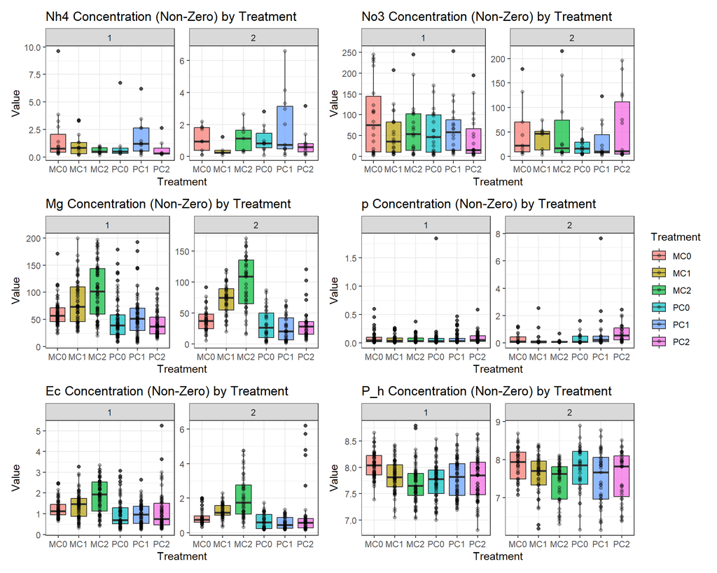

```r
# Function to create boxplots for each response variable
plot_concentration <- function(r, data) {
  data %>%
    filter(.data[[r]] > 0) %>% # We only plot non-zero values for clarity
    ggplot(aes(x = treatment, y = .data[[r]], fill = treatment)) +
    geom_boxplot(alpha = 0.7) +
    geom_point(alpha = 0.3) +
    facet_wrap(vars(study_year), scales = "free") +
    labs(
      title = paste(tools::toTitleCase(r), "Concentration (Non-Zero) by Treatment"),
      x = "Treatment",
      y = "Value",
      fill = "Treatment"
    ) +
    theme_bw()
}

# Create and display the plots
plots_0 <- map(response_vars, plot_concentration, data = df_combined_LOD_0)
wrap_plots(plots_0, ncol = 2, guides = "collect")
```

## Modeling Approach 1: Censored Models for Data with LODs (`brms`)

This is a statistically robust approach for `nh4`, `no3`, `mg`, and `p`. It accounts for the fact that LOD values are not true zeros but are values below a certain threshold. We use the `brms` package for Bayesian modeling.

*Note: Bayesian models are computationally intensive and can take a long time to run. For this report, we are loading pre-fitted model objects.*

### Censored Model for Nitrate (`no3`)

```r
# fit_no3 <- brm(
#   bf(no3 | cens(no3_cens) ~ treatment * date + (1 | site_block_id) + (1 | trt_site_block_id)),
#   data = lc_model_data, family = Gamma(link = "log"),
#   iter = 4000, warmup = 1000, chains = 4, cores = 4, seed = 12345,
#   file = "models/fit_no3"
# )
fit_no3 <- read_rds(here::here("models", "fit_no3.rds"))
```

```
Warning: Censored responses are not shown in 'pp_check'.
```

```
Warning: Removed 3756 rows containing non-finite outside the scale range
(`stat_density()`).
```

```
Warning: Removed 41 rows containing non-finite outside the scale range
(`stat_density()`).
```

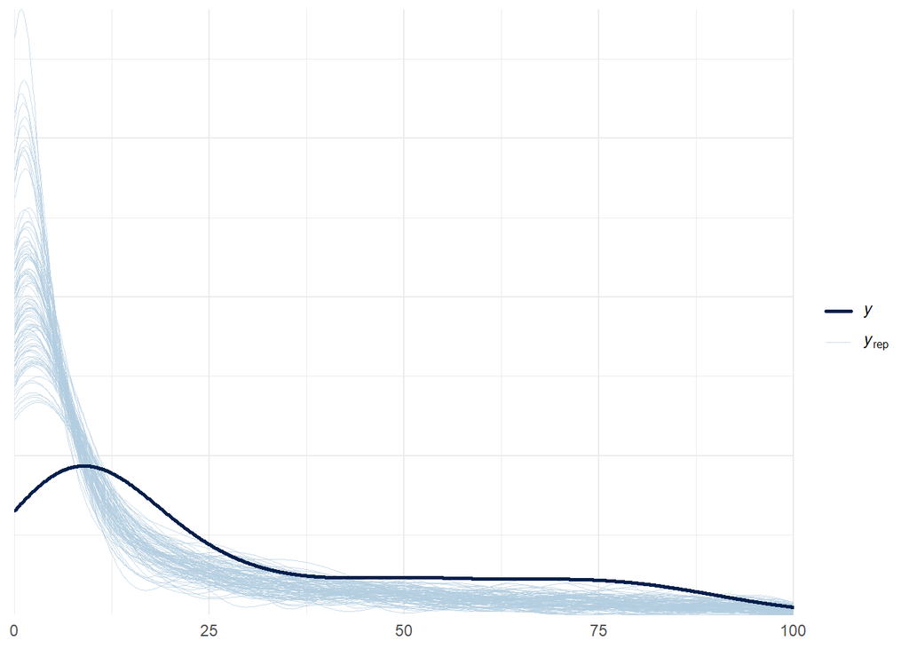

```r
# summary(fit_no3)
pp_check(fit_no3, ndraws = 100) + xlim(0, 100)
```

### Censored Model for Ammonium (`nh4`)

```r
# fit_nh4 <- brm(
#   bf(nh4 | cens(nh4_cens) ~ treatment * date + (1 | site_block_id) + (1 | trt_site_block_id)),
#   data = lc_model_data, family = Gamma(link = "log"),
#   iter = 4000, warmup = 1000, chains = 4, cores = 4, seed = 12345,
#   file = "models/fit_no3"
# )
fit_nh4 <- read_rds(here::here("models", "fit_nh4.rds"))
```

```
Warning: Censored responses are not shown in 'pp_check'.
```

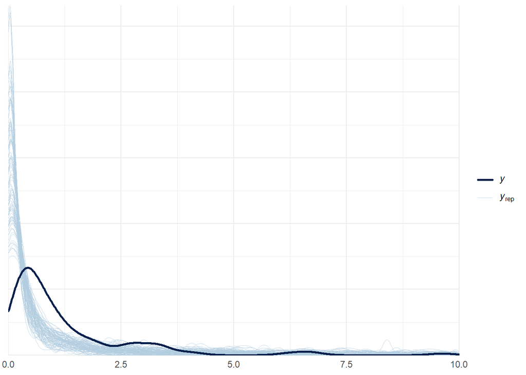

```r
# summary(fit_nh4)
pp_check(fit_nh4, ndraws = 100) + xlim(0, 10)
```

### Censored Model for Magnesium (`mg`)

```r
# fit_mg <- brm(
#   bf(mg | cens(mg_cens) ~ treatment * date + (1 | site_block_id)) + (1 | trt_site_block_id)),
#   data = lc_model_data, family = Gamma(link = "log"),
#   iter = 4000, warmup = 1000, chains = 4, cores = 4, seed = 12345,
#   file = "models/fit_mg"
# )
fit_mg <- read_rds(here::here("models", "fit_mg.rds"))
```

```r
summary(fit_mg)
```

```
 Family: gamma
  Links: mu = log; shape = identity
Formula: mg | cens(mg_censored) ~ date * treatment + (1 | site_block_id) + (1 | trt_site_block_id)
   Data: lc_model_data (Number of observations: 633)
  Draws: 4 chains, each with iter = 5000; warmup = 1000; thin = 1;
         total post-warmup draws = 16000

Multilevel Hyperparameters:
~site_block_id (Number of levels: 8)
              Estimate Est.Error l-95% CI u-95% CI Rhat Bulk_ESS Tail_ESS
sd(Intercept)     0.40      0.18     0.17     0.87 1.00     2032      743

~trt_site_block_id (Number of levels: 48)
              Estimate Est.Error l-95% CI u-95% CI Rhat Bulk_ESS Tail_ESS
sd(Intercept)     0.38      0.05     0.29     0.50 1.00     6068     9749

Regression Coefficients:
                            Estimate Est.Error l-95% CI u-95% CI Rhat Bulk_ESS
Intercept                       3.90      0.30     3.29     4.45 1.00      869
date2024M01M12                  0.20      0.24    -0.28     0.68 1.00     2141
date2024M01M23                  0.25      0.24    -0.23     0.71 1.00     1933
date2024M02M07                 -0.01      0.24    -0.48     0.46 1.00     2122
date2024M02M21                  0.12      0.25    -0.36     0.62 1.00     2153
date2024M03M06                  0.19      0.25    -0.30     0.66 1.00     1806
date2024M03M22                  0.38      0.24    -0.09     0.86 1.00     1848
date2024M04M04                  0.48      0.26    -0.02     0.98 1.00     2203
date2024M04M16                  0.34      0.24    -0.14     0.81 1.00     2128
date2025M02M08                 -0.66      0.24    -1.14    -0.19 1.00     1980
date2025M02M15                 -0.48      0.25    -0.97     0.00 1.00     2085
date2025M03M04                 -0.35      0.26    -0.85     0.16 1.00     2299
date2025M03M16                 -0.14      0.24    -0.61     0.33 1.00     2104
date2025M03M27                  0.03      0.26    -0.47     0.53 1.00     2299
date2025M04M11                  0.21      0.27    -0.31     0.75 1.00     1922
treatmentMC1                    0.86      0.31     0.25     1.47 1.00     2513
treatmentMC2                    0.58      0.32    -0.04     1.22 1.00     2455
treatmentPC0                    0.01      0.32    -0.62     0.62 1.00     2577
treatmentPC1                    0.48      0.31    -0.12     1.09 1.00     2187
treatmentPC2                    0.10      0.35    -0.57     0.79 1.00     1728
date2024M01M12:treatmentMC1    -0.27      0.33    -0.92     0.38 1.00     2988
date2024M01M23:treatmentMC1    -0.32      0.33    -0.96     0.33 1.00     2830
```

[output cut: 152 more lines]

```
date2024M04M16:treatmentPC2     6883
date2025M02M08:treatmentPC2     7278
date2025M02M15:treatmentPC2     7244
date2025M03M04:treatmentPC2     6715
date2025M03M16:treatmentPC2     6105
date2025M03M27:treatmentPC2     3233
date2025M04M11:treatmentPC2     7080

Further Distributional Parameters:
      Estimate Est.Error l-95% CI u-95% CI Rhat Bulk_ESS Tail_ESS
shape     5.78      0.35     5.11     6.48 1.00    13355    11217

Draws were sampled using sampling(NUTS). For each parameter, Bulk_ESS
and Tail_ESS are effective sample size measures, and Rhat is the potential
scale reduction factor on split chains (at convergence, Rhat = 1).
```

```
Warning: Censored responses are not shown in 'pp_check'.
```

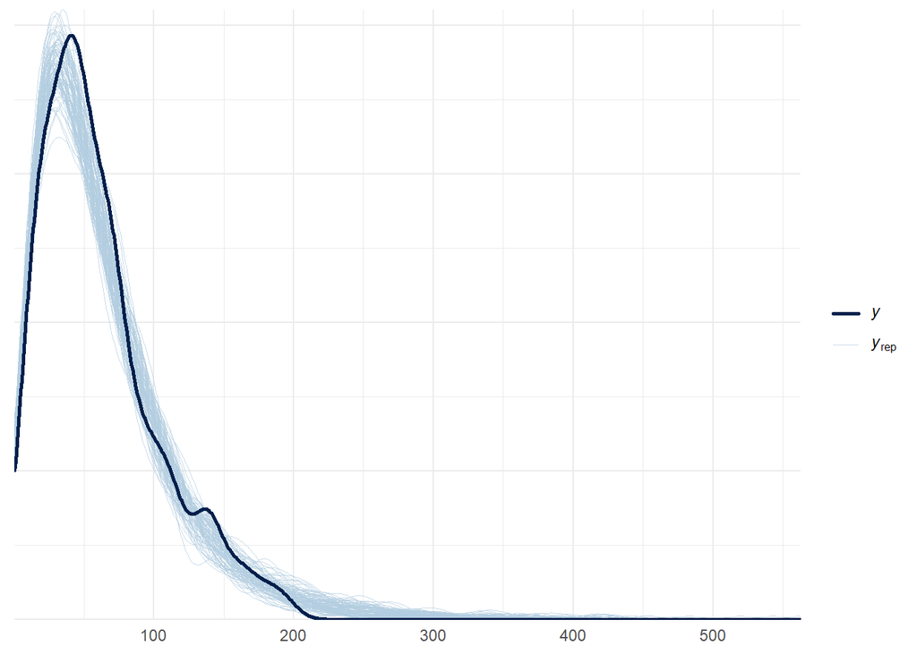

```r
pp_check(fit_mg, ndraws = 100)
```

The `mg` model appears to have converged much better than the `nh4` and `no3` models, with few warnings. The `pp_check` shows a good fit between the model’s predictions and the observed data. This suggests the censored Gamma model is a good choice for `mg`.

### Censored Model for Phosphate (`p`)

```r
# fit_p <- brm(
#   bf(p | cens(p_cens) ~ treatment * date + (1 | site_block_id)) + (1 | trt_site_block_id)),
#   data = lc_model_data, family = Gamma(link = "log"),
#   iter = 4000, warmup = 1000, chains = 4, cores = 4, seed = 12345,
#   file = "models/fit_p"
# )
fit_p <- read_rds(here::here("models", "fit_p.rds"))
```

```
Warning: Censored responses are not shown in 'pp_check'.
```

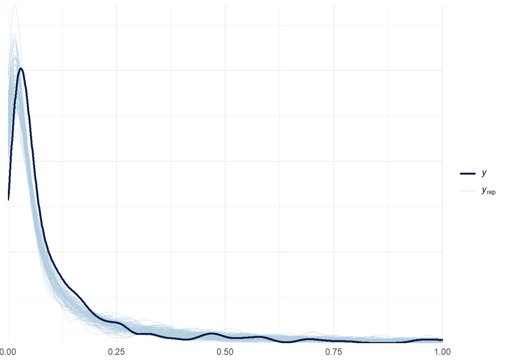

```r
# summary(fit_p)
pp_check(fit_p, ndraws = 100) + xlim(0, 1)
```

## Modeling Approach 2: Zero-Inflated Models (`glmmTMB`)

This approach models the data in two parts: a logistic regression for the probability of a zero vs. a non-zero value, and a separate model (e.g., Gamma or Lognormal) for the non-zero values. This is an alternative for `nh4`, `no3`, and `p`.

*Note: We are only modeling Study Year 1 for these models.*

### Zero-Inflated Model for Nitrate (`no3`)

```r
fit_no3_zi <- glmmTMB(
  no3 ~ treatment * date + (1 | site_block_id) + (1 | trt_site_block_id),
  ziformula = ~treatment,
  data = df_model,
  family = glmmTMB::lognormal(link = "log")
)
```

```
Warning in finalizeTMB(TMBStruc, obj, fit, h, data.tmb.old): Model convergence
problem; non-positive-definite Hessian matrix. See vignette('troubleshooting')
```

```r
# summary(fit_no3_zi)
```

### Zero-Inflated Model for Ammonium (`nh4`)

```r
fit_nh4_zi <- glmmTMB(
  nh4 ~ treatment * date + (1 | site_block_id) + (1 | trt_site_block_id),
  ziformula = ~treatment,
  data = df_model,
  family = glmmTMB::lognormal(link = "log")
)
```

```
Warning in finalizeTMB(TMBStruc, obj, fit, h, data.tmb.old): Model convergence
problem; non-positive-definite Hessian matrix. See vignette('troubleshooting')
```

```r
# summary(fit_nh4_zi)
```

```r
emmeans(fit_nh4_zi, specs = ~ treatment | date, type = "response") %>%
   cld(Letters = LETTERS, adjust = "tukey")

pred_effects <- ggpredict(fit_nh4_zi, terms = c("date", "treatment"))
pred_data <- as.data.frame(pred_effects)

ggplot() +

  geom_point(
    data = df_model %>% mutate(group = treatment),
    aes(x = date, y = nh4),
    alpha = 0.5,
    color = "gray50",
    position = position_jitter(width = 0.2, height = 0)
  ) +

  geom_ribbon(
    data = pred_data,
    aes(x = x, ymin = conf.low, ymax = conf.high, group = group),
    alpha = 0.2,
    fill = "cornflowerblue"
  ) +

  geom_line(
    data = pred_data,
    aes(x = x, y = predicted, group = group),
    color = "cornflowerblue",
    linewidth = 1
  ) +

  facet_wrap(~ group, scales = "free_y") +

  labs(
    x = "Date",
    y = "Ammonium (NH4) Concentration",
    title = "Predicted Values of NH4, Faceted by Treatment"
  ) +
  theme_bw() +
  theme(axis.text.x = element_text(angle = 45, hjust = 1))
# print(pred_effects)
```

[output not shown]

### Zero-Inflated Model for Phosphate (`p`)

```r
fit_p_zi <- glmmTMB(
  p ~ treatment * date + (1 | site_block_id) + (1 | trt_site_block_id),
  ziformula = ~treatment,
  data = df_model,
  family = glmmTMB::lognormal(link = "log")
)

Anova(fit_p_zi)
```

```
Analysis of Deviance Table (Type II Wald chisquare tests)

Response: p
                 Chisq Df Pr(>Chisq)
treatment       26.422  5  7.389e-05 ***
date           358.255  8  < 2.2e-16 ***
treatment:date  36.069 40     0.6479
---
Signif. codes:  0 '***' 0.001 '**' 0.01 '*' 0.05 '.' 0.1 ' ' 1
```

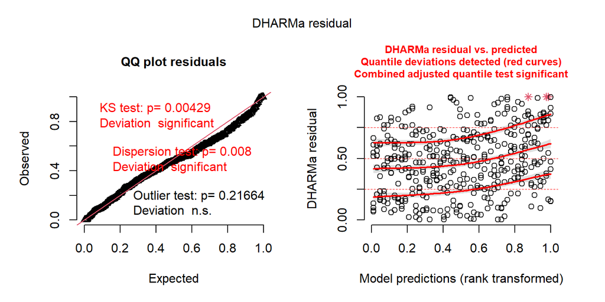

```r
simulationOutput <- simulateResiduals(fittedModel = fit_p_zi, n = 500)
plot(simulationOutput)
```

```r
emmeans(fit_p_zi, specs = ~ treatment, type = "response") %>%
  cld(Letters = LETTERS, adjust = "tukey")
```

```
NOTE: Results may be misleading due to involvement in interactions
```

```
Note: adjust = "tukey" was changed to "sidak"
because "tukey" is only appropriate for one set of pairwise comparisons
```

```
 treatment response      SE  df asymp.LCL asymp.UCL .group
 PC0         0.0580 0.00523 Inf    0.0457    0.0735  A
 MC1         0.0625 0.00578 Inf    0.0490    0.0797  A
 MC2         0.0632 0.00599 Inf    0.0493    0.0811  A
 PC1         0.0693 0.00583 Inf    0.0555    0.0865  AB
 MC0         0.0726 0.00636 Inf    0.0576    0.0914  AB
 PC2         0.0878 0.00689 Inf    0.0714    0.1079   B

Results are averaged over the levels of: date
Confidence level used: 0.95
Conf-level adjustment: sidak method for 6 estimates
Intervals are back-transformed from the log scale
P value adjustment: tukey method for comparing a family of 6 estimates
Tests are performed on the log scale
significance level used: alpha = 0.05
NOTE: If two or more means share the same grouping symbol,
      then we cannot show them to be different.
      But we also did not show them to be the same.
```

```r
pred_effects <- ggpredict(fit_p_zi, terms = c("date", "treatment"))
```

```
You are calculating adjusted predictions on the population-level (i.e.
  `type = "fixed"`) for a *generalized* linear mixed model.
  This may produce biased estimates due to Jensen's inequality. Consider
  setting `bias_correction = TRUE` to correct for this bias.
  See also the documentation of the `bias_correction` argument.
```

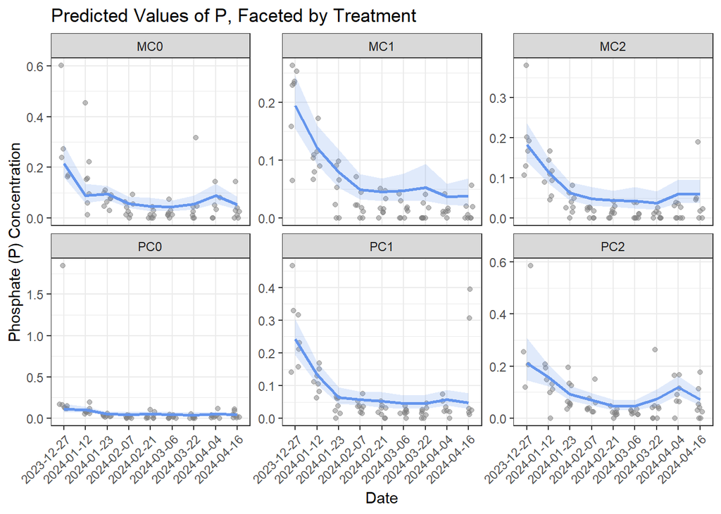

```r
pred_data <- as.data.frame(pred_effects)

ggplot() +

  geom_point(
    data = df_model %>% mutate(group = treatment),
    aes(x = date, y = p),
    alpha = 0.5,
    color = "gray50",
    position = position_jitter(width = 0.2, height = 0)
  ) +

  geom_ribbon(
    data = pred_data,
    aes(x = x, ymin = conf.low, ymax = conf.high, group = group),
    alpha = 0.2,
    fill = "cornflowerblue"
  ) +

  geom_line(
    data = pred_data,
    aes(x = x, y = predicted, group = group),
    color = "cornflowerblue",
    linewidth = 1
  ) +

  facet_wrap(~ group, scales = "free_y") +

  labs(
    x = "Date",
    y = "Phosphate (P) Concentration",
    title = "Predicted Values of P, Faceted by Treatment"
  ) +
  theme_bw() +
  theme(axis.text.x = element_text(angle = 45, hjust = 1))
```

```r
# print(pred_effects)
```

The zero-inflated model for `p` converges properly, and the DHARMa diagnostics show some deviations, suggesting this model may not be a good fit.

## Models for Data with No LODs (`p_h` and `ec`)

For variables like pH and EC that do not have a zero-inflation problem, we can use more standard generalized linear mixed models.

### Model for pH (`p_h`)

```r
fit_lme_ph <- lme(
  fixed = p_h ~ as.factor(date) * treatment,
  random = list(
    site_block_id = ~ 1, # Random intercept for site:block combinations
    trt_site_block_id = ~ 1 # Random intercept for treatment:site:block combinations
  ),
  data = df_model,
  na.action = na.exclude
)

anova(fit_lme_ph)
```

```
                          numDF denDF  F-value p-value
(Intercept)                   1   302 9775.941  <.0001
as.factor(date)               8   302    7.600  <.0001
treatment                     5    35    4.906  0.0017
as.factor(date):treatment    40   302    0.519  0.9933
```

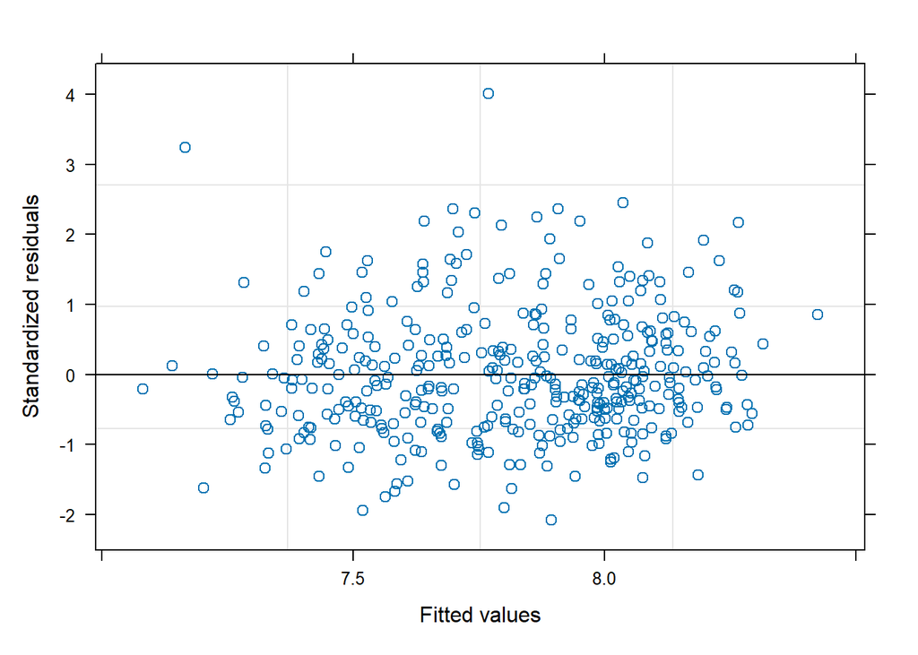

```r
plot(fit_lme_ph)
```

```r
emmeans(fit_lme_ph, specs = ~ treatment) %>%
  cld(Letters = LETTERS, adjust = "tukey")
```

```
NOTE: Results may be misleading due to involvement in interactions
```

```
Note: adjust = "tukey" was changed to "sidak"
because "tukey" is only appropriate for one set of pairwise comparisons
```

```
 treatment emmean     SE df lower.CL upper.CL .group
 MC2         7.69 0.0928  7     7.35     8.02  A
 PC0         7.75 0.0925  7     7.42     8.09  A
 PC2         7.80 0.0933  7     7.47     8.14  A
 PC1         7.81 0.0929  7     7.48     8.15  A
 MC1         7.83 0.0929  7     7.49     8.16  AB
 MC0         8.04 0.0932  7     7.70     8.38   B

Results are averaged over the levels of: date
Degrees-of-freedom method: containment
Confidence level used: 0.95
Conf-level adjustment: sidak method for 6 estimates
P value adjustment: tukey method for comparing a family of 6 estimates
significance level used: alpha = 0.05
NOTE: If two or more means share the same grouping symbol,
      then we cannot show them to be different.
      But we also did not show them to be the same.
```

```r
emmeans(fit_lme_ph, specs = ~ treatment | date) %>%
  cld(Letters = LETTERS, adjust = "tukey")
```

```
Note: adjust = "tukey" was changed to "sidak"
because "tukey" is only appropriate for one set of pairwise comparisons
```

```
date = 2023-12-27:
 treatment emmean    SE df lower.CL upper.CL .group
 MC1         7.60 0.133  7     7.12     8.08  A
 PC1         7.67 0.127  7     7.20     8.13  A
 MC2         7.67 0.133  7     7.19     8.15  A
 PC2         7.77 0.152  7     7.22     8.32  A
 PC0         7.90 0.127  7     7.44     8.36  A
 MC0         8.07 0.141  7     7.56     8.58  A

date = 2024-01-12:
 treatment emmean    SE df lower.CL upper.CL .group
 MC2         7.77 0.123  7     7.32     8.21  A
 PC2         7.84 0.133  7     7.36     8.32  A
 PC1         7.85 0.127  7     7.38     8.31  A
 PC0         7.86 0.123  7     7.42     8.31  A
 MC1         7.94 0.127  7     7.48     8.40  A
 MC0         8.18 0.127  7     7.72     8.64  A

date = 2024-01-23:
 treatment emmean    SE df lower.CL upper.CL .group
 MC2         7.78 0.133  7     7.30     8.26  A
 PC0         7.84 0.123  7     7.39     8.28  A
 PC1         7.92 0.127  7     7.46     8.38  A
 PC2         8.01 0.123  7     7.56     8.45  A
 MC1         8.04 0.133  7     7.55     8.52  A
 MC0         8.11 0.123  7     7.67     8.55  A

date = 2024-02-07:
 treatment emmean    SE df lower.CL upper.CL .group
 PC0         7.82 0.123  7     7.38     8.26  A
 PC2         7.88 0.123  7     7.43     8.32  A
 MC2         7.91 0.123  7     7.47     8.35  A
 MC1         7.96 0.123  7     7.52     8.41  A
 PC1         7.99 0.123  7     7.55     8.44  A
 MC0         8.17 0.123  7     7.73     8.62  A

date = 2024-02-21:
 treatment emmean    SE df lower.CL upper.CL .group
 MC2         7.63 0.123  7     7.18     8.07  A
 PC0         7.70 0.123  7     7.26     8.15  A
```

[output cut: 34 more lines]

```
 MC2         7.49 0.127  7     7.03     7.95  A
 PC0         7.54 0.123  7     7.09     7.98  AB
 PC2         7.62 0.123  7     7.18     8.07  AB
 PC1         7.66 0.133  7     7.18     8.14  AB
 MC1         7.71 0.123  7     7.26     8.15  AB
 MC0         7.93 0.127  7     7.47     8.39   B

Degrees-of-freedom method: containment
Confidence level used: 0.95
Conf-level adjustment: sidak method for 6 estimates
P value adjustment: tukey method for comparing a family of 6 estimates
significance level used: alpha = 0.05
NOTE: If two or more means share the same grouping symbol,
      then we cannot show them to be different.
      But we also did not show them to be the same.
```

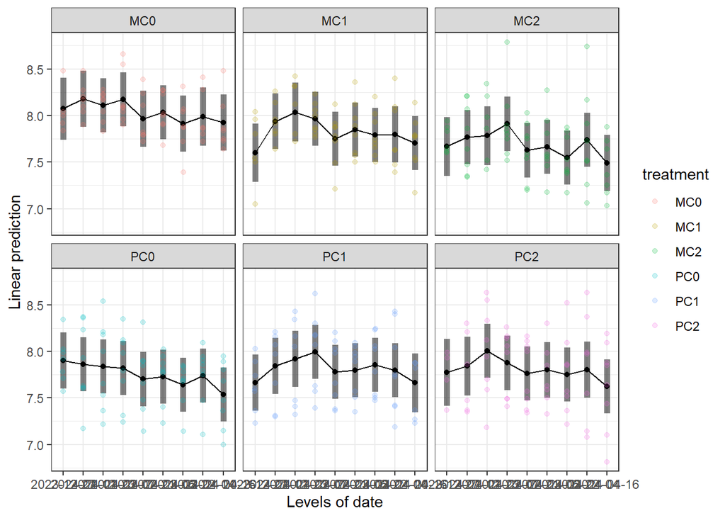

```r
emmip(fit_lme_ph, ~ date | treatment, CIs = T) +
  geom_point(data = df_model,
             aes(x = date, y = p_h, color = treatment),
             alpha = 0.2,
             position = position_jitterdodge(jitter.width = 0.1, dodge.width = 0.1)) +
  theme_bw()
```

The model summary shows significant effects of treatment. The diagnostic plots show randomly scattered residuals, suggesting the model assumptions are met and this is a reliable model.

### Model for EC (`ec`)

The residuals for the GLMM for EC showed fanning, therefore a Gamma GLMM is more appropriate than a standard linear model.

```r
fit_ec_gamma <- glmer(
  ec ~ date * treatment +
    (1 | site_block_id) +
    (1 | trt_site_block_id),
  data = df_model,
  family = Gamma(link = "log"),
  control = glmerControl(optimizer = "bobyqa"), # default optimizer did not converge
  na.action = na.exclude
)
Anova(fit_ec_gamma)
```

```
Analysis of Deviance Table (Type II Wald chisquare tests)

Response: ec
                 Chisq Df Pr(>Chisq)
date           190.311  8  < 2.2e-16 ***
treatment       25.604  5  0.0001065 ***
date:treatment  71.103 40  0.0017755 **
---
Signif. codes:  0 '***' 0.001 '**' 0.01 '*' 0.05 '.' 0.1 ' ' 1
```

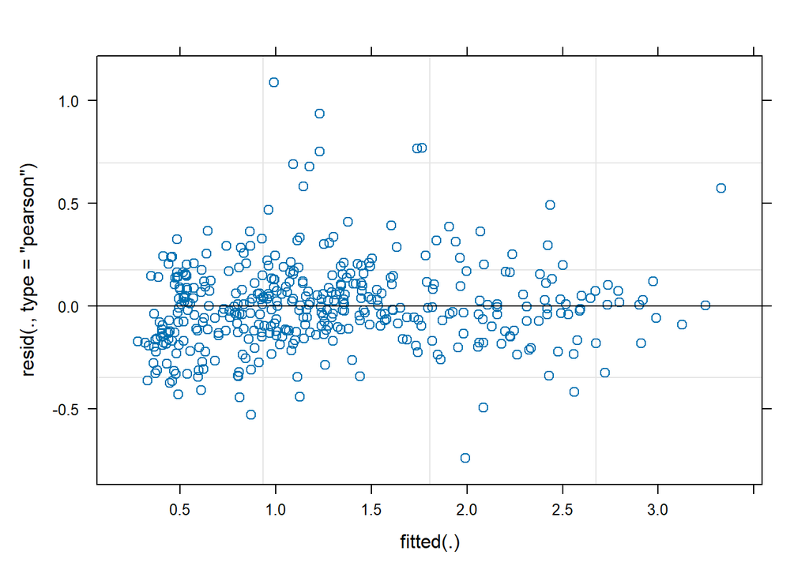

```r
plot(fit_ec_gamma)
```

```r
emmeans(fit_ec_gamma, specs = ~ treatment | date, type = "response") %>%
  cld(Letters = LETTERS, adjust = "tukey")
```

```
Note: adjust = "tukey" was changed to "sidak"
because "tukey" is only appropriate for one set of pairwise comparisons
```

```
date = 2023-12-27:
 treatment response    SE  df asymp.LCL asymp.UCL .group
 PC0          0.907 0.212 Inf     0.490      1.68  A
 PC2          1.031 0.250 Inf     0.545      1.95  AB
 PC1          1.283 0.297 Inf     0.697      2.36  AB
 MC0          1.319 0.311 Inf     0.709      2.45  AB
 MC2          1.862 0.439 Inf     1.002      3.46   B
 MC1          1.874 0.436 Inf     1.016      3.46   B

date = 2024-01-12:
 treatment response    SE  df asymp.LCL asymp.UCL .group
 PC0          0.827 0.192 Inf     0.449      1.52  A
 PC1          1.005 0.233 Inf     0.546      1.85  AB
 PC2          1.054 0.246 Inf     0.570      1.95  AB
 MC0          1.281 0.295 Inf     0.699      2.35  AB
 MC1          1.674 0.390 Inf     0.907      3.09   B
 MC2          1.781 0.411 Inf     0.969      3.27   B

date = 2024-01-23:
 treatment response    SE  df asymp.LCL asymp.UCL .group
 PC0          0.697 0.162 Inf     0.379      1.28  A
 PC2          0.792 0.181 Inf     0.434      1.45  A
 PC1          0.915 0.212 Inf     0.497      1.68  AB
 MC0          1.129 0.257 Inf     0.620      2.06  ABC
 MC1          1.614 0.373 Inf     0.879      2.96   BC
 MC2          1.896 0.438 Inf     1.033      3.48    C

date = 2024-02-07:
 treatment response    SE  df asymp.LCL asymp.UCL .group
 PC1          0.841 0.193 Inf     0.460      1.54  A
 PC2          0.865 0.198 Inf     0.474      1.58  A
 PC0          0.883 0.205 Inf     0.480      1.63  A
 MC0          1.166 0.266 Inf     0.640      2.12  A
 MC1          1.306 0.301 Inf     0.711      2.40  A
 MC2          1.519 0.351 Inf     0.827      2.79  A

date = 2024-02-21:
 treatment response    SE  df asymp.LCL asymp.UCL .group
 PC1          0.902 0.207 Inf     0.493      1.65  A
 PC0          0.921 0.213 Inf     0.500      1.69  AB
```

[output cut: 35 more lines]

```
 PC2          0.604 0.138 Inf     0.331      1.10  A
 PC0          0.616 0.143 Inf     0.335      1.13  A
 MC1          0.779 0.180 Inf     0.424      1.43  AB
 MC0          1.008 0.232 Inf     0.551      1.85  AB
 MC2          1.228 0.286 Inf     0.665      2.27   B

Confidence level used: 0.95
Conf-level adjustment: sidak method for 6 estimates
Intervals are back-transformed from the log scale
P value adjustment: tukey method for comparing a family of 6 estimates
Tests are performed on the log scale
significance level used: alpha = 0.05
NOTE: If two or more means share the same grouping symbol,
      then we cannot show them to be different.
      But we also did not show them to be the same.
```

```
Warning: Removed 28 rows containing missing values or values outside the scale range
(`geom_point()`).
```

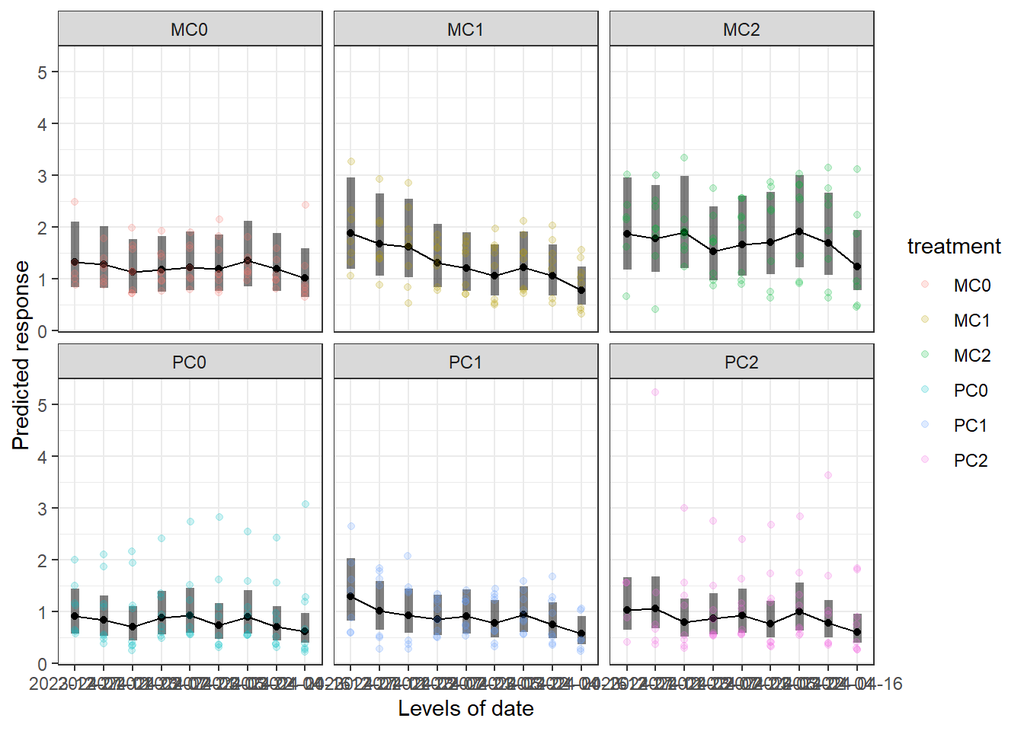

```r
emmip(fit_ec_gamma, ~ date | treatment, type = "response", CIs = T) +
  geom_point(data = df_model,
             aes(x = date, y = ec, color = treatment),
             alpha = 0.2,
             position = position_jitterdodge(jitter.width = 0.1, dodge.width = 0.1)) +
  theme_bw()
```

The model converged without warnings. The diagnostic plots show randomly scattered residuals, suggesting the model assumptions are met and this is a reliable model.

## Summary and Recommendations

- **Models for `p_h` and `ec`:** For pH (`p_h`) and EC (`ec`), the standard linear mixed model and Gamma GLMM, respectively, fit the data well, converged without issues, and passed diagnostic checks.
- **Censored Models are Promising:** The Bayesian censored models (`brms`) are theoretically the most robust approach for the data with LODs. The `mg` model worked very well. However, the models for `nh4`, `no3`, and `p` struggled to converge.
  - **Recommendation:** For the `brms` models that had issues, I suggest increasing the number of iterations (e.g., `iter = 6000`, `warmup = 2000`) and perhaps trying a more informative prior distribution (currently brms is selecting this for us) if you have prior knowledge about the parameters. This may help the models converge.
- **Zero-Inflated Models are a Good Alternative:** The zero-inflated models (`glmmTMB`) also faced convergence issues.
  - **Recommendation:** Try simplifying the zero-inflated models. For instance, you could remove the interaction term (`treatment * date`) and use additive effects (`treatment + date`) to see if that helps with convergence.
- Since we did not find a good model fit for `nh4`, `no3`, and `p`, we suggest fitting a binomial GLMM where 1 = above LOD and 0 = below LOD since the convergence issues on our models may come from some combinations of treatment and date not having any non-LOD values.